# NYC helios setup: population, schools and ventilation

This report summarises the New York City inputs used in helios-nyc: the synthetic household population, public school sizes, the population helios generates from them, and the school ventilation assumptions. Charts are static; each has a table with the underlying values.

# Key numbers

| Measure | Value |
| --- | --- |
| Households (five boroughs) | 3,166,264 |
| People in households | 7,847,492 |
| Mean household size | 2.48 |
| Public schools (2018-19, open with enrollment) | 1,817 |
| Students enrolled | 1,065,471 |
| Students per full-time-equivalent teacher | 13.5 |

Sources: households from the RTI synthetic population pipeline (2015-2019 American Community Survey, New York State filtered to the five boroughs, with stochastic rounding of household counts); schools from the NCES Common Core of Data school directory for 2018-19.

# Households and age structure

## People by age group

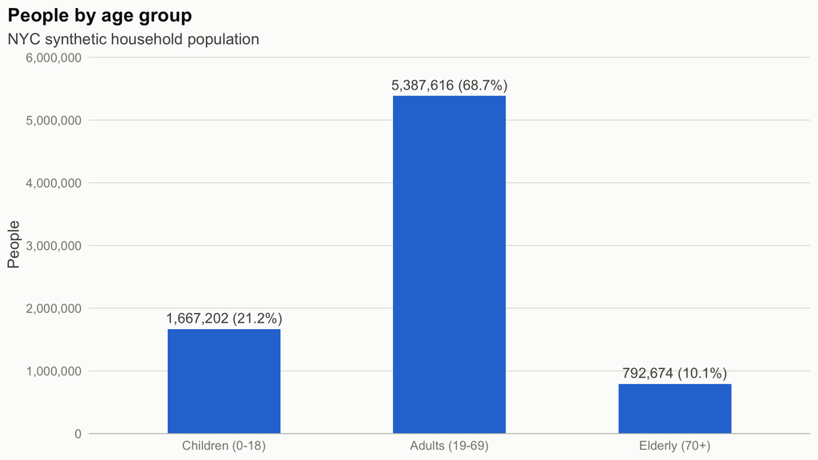

| Age group | People | Share |
| --- | --- | --- |
| Children (0-18) | 1,667,202 | 21.2% |
| Adults (19-69) | 5,387,616 | 68.7% |
| Elderly (70+) | 792,674 | 10.1% |

## Household size: model population versus the Census

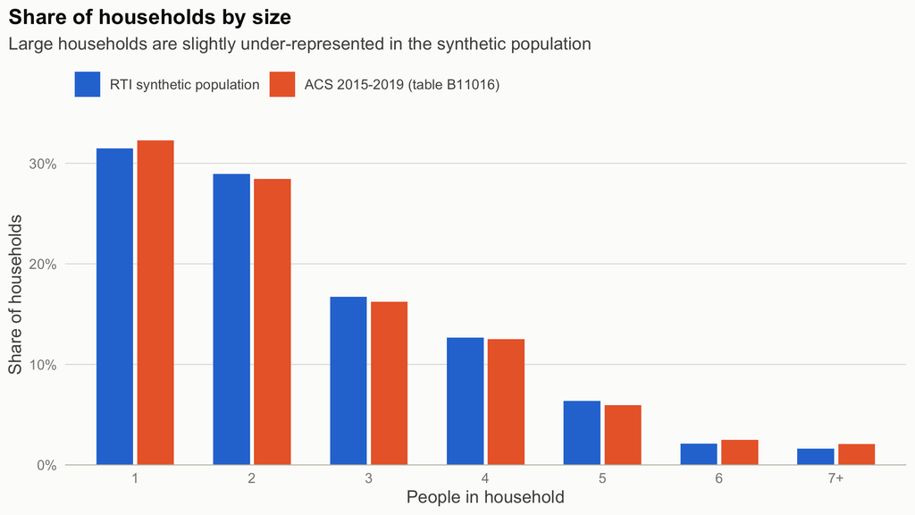

| People in household | RTI synthetic population | ACS 2015-2019 (table B11016) |
| --- | --- | --- |
| 1 | 31.50% | 32.29% |
| 2 | 28.93% | 28.45% |
| 3 | 16.73% | 16.22% |
| 4 | 12.68% | 12.51% |
| 5 | 6.38% | 5.95% |
| 6 | 2.13% | 2.51% |
| 7+ | 1.64% | 2.07% |

# Schools

## Students per school

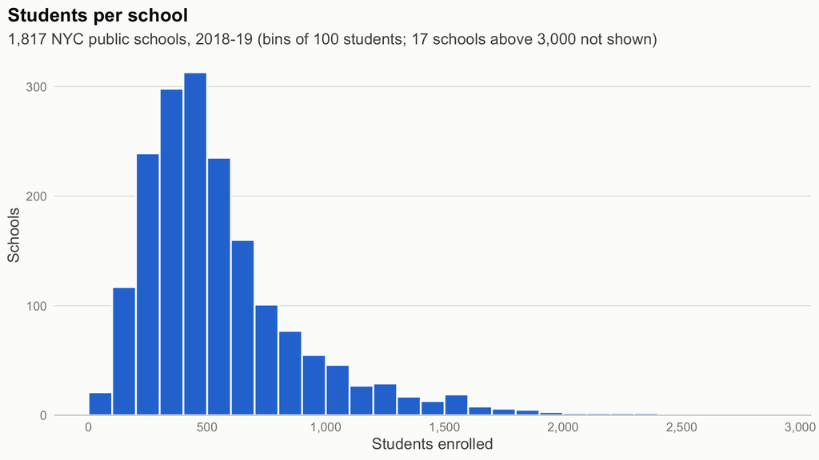

| Statistic | Students enrolled |
| --- | --- |
| Minimum | 1 |
| 25th percentile | 324 |
| Median | 473 |
| Mean | 586 |
| 75th percentile | 682 |
| 95th percentile | 1,347 |
| Maximum | 5,934 |

## Students by borough

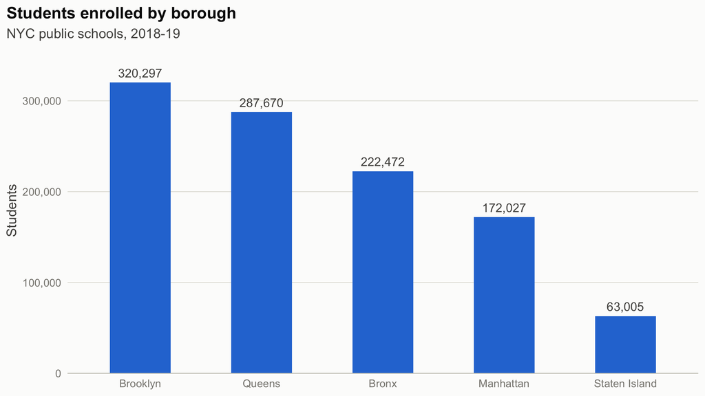

| Borough | Schools | Students |
| --- | --- | --- |
| Brooklyn | 562 | 320,297 |
| Queens | 379 | 287,670 |
| Bronx | 438 | 222,472 |
| Manhattan | 356 | 172,027 |
| Staten Island | 82 | 63,005 |